# COMPLEX CLUSTERS BASED ON MULTIPLE DIMENSIONS

### SECTIONS

1. Summary
2. Method
3. Clusters verbally described
4. Clusters visually described
5. Table of aggregated values by cluster
6. Hierachical clustering on principal components
7. Clusters displayed on scatter plots
8. Variable relevance per cluster
9. Clusters over time
10. Cluster populations by college and major institutions

### 1. SUMMARY

This shows principal investigators sorted into five clusters using multiple criteria.

### 2. METHOD

First, principal investigators (PI’s) with three or fewer proposals are filtered out. 1,265 principal investigators (43%) are removed and 1,672 principal investigators (57%) are kept.

Second, several variables are calculated per principal investigator:

- Sum of funds requested (won and lost)
- Count of proposals (won and lost)
- Mean and median of funds requested (won and lost)
- Rate of proposals won (count rate)
- Rate of funds requested won (sum rate)
- Total count and sum

Third, variables except rates are scaled with a natural log transformation first, then all variables are centered and scaled.

Fourth, principle components are extracted.

Fifth, hierarchical clustering using Euclidean distance and Ward’s method is used to produce five clusters.

The clusters are named, described verbally and visually, and the cluster populations by colleges and major institutions are shown.

### 3. CLUSTERS VERBALLY DESCRIBED

**CLUSTER 1: PERFECT**  
Principal investigators in Cluster 1 are perfect in their attempts with 100% win rates of relatively smaller proposals.

A high proportion of PI’s from the School of Business are found here.

It has a population of 65 PIs (3.9%) and accounts for only 1.7% of total requested funds won.

**CLUSTER 2: PRECISE**  
Principal investigators in Cluster 2 don’t have the perfect record of Cluster 1, but win a high proportion of their proposals on both a count and sum basis. They bring in as much as Cluster 4 in total funds requested won through racking up lots of relatively smaller wins.

It has a population of 397 PIs (23.7%) and accounts for 13.3% of total requested funds won.

**CLUSTER 3: PIPE DREAMS**  
Cluster 3 contains principal investigators with zero and near-zero win rates. They ambitiously attempt proposals as large as the principal investigators in Clusters 4 and 5 – just without success.

It has high proportions of PI’s from the colleges of Law, Health, and Social and Behavioral Sciences.

It has a population of 88 PIs (5.3%) and accounts for 0% of total requested funds won.

**CLUSTER 4: PLUCKY**  
Cluster 4 contains principal investigators who mainly differ from Cluster 5 in the count of proposals submitted. They submit equivalently large proposals, just far fewer – less than a third of the proposals submitted by Cluster 5. Some of this is due to longevity (PI’s in Cluster 4 have been submitting bids for a median of 1.86 years compared to 3.7 years in Cluster 5), but some is also due to the rate of submission: PI’s in Cluster 5 submit a median of 30% more bids per year.

Cluster 4 PI’s also slightly lag Cluster 5 PI’s in win rates (count and sum) as well.

It has a population of 558 PIs (33.4%) and accounts for 14.2% of total requested funds won.

**CLUSTER 5: PROLIFIC**  
Cluster 5 contains principal investigators with a prolific record of submission. They submit a large number of proposals – triple Cluster 4, the next highest – with impressive win rates on large proposals. These are the workhorses of University of Utah research.

Principal investigators from the institutions (EGI, CTSI, CVRTI, ICSE, and SCI) tend to show up here.

It has a population of 564 PIs (33.7%) and accounts for a large majority (70.8%) of total requested funds won.

### 4. CLUSTERS VISUALLY DESCRIBED

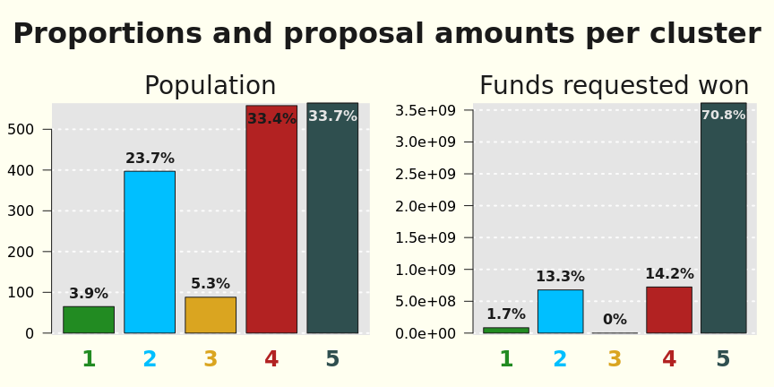

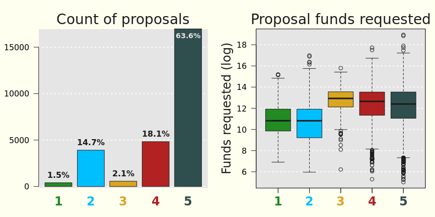

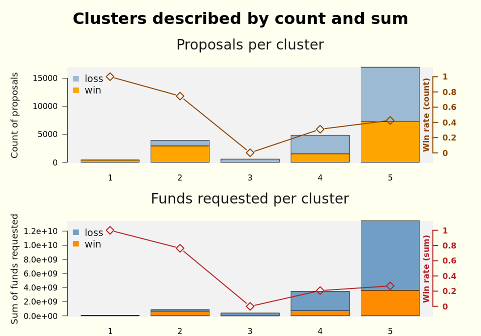

### 5. TABLE OF AGGREGATED VALUES BY CLUSTER

Aggregated Metrics by Complex Cluster

| cluster | population | pop_perc | count_total | count_perc | win.sum | sum_perc | win.count | win.mean | win.median | loss.sum | loss.count | loss.mean | loss.median | sum.rate | count.rate | color |
| --- | --- | --- | --- | --- | --- | --- | --- | --- | --- | --- | --- | --- | --- | --- | --- | --- |
| 1 | 65 | 3.9 | 400 | 2 | 84,000,000 | 2 | 400 | 208,000 | 50,000 | 0 | 0 | 0 | 0 | 1.00 | 1.00 | forestgreen |
| 2 | 397 | 23.7 | 3,910 | 15 | 678,000,000 | 13 | 2,920 | 232,000 | 47,000 | 210,000,000 | 1,000 | 210,700 | 68,200 | 0.76 | 0.75 | deepskyblue |
| 3 | 88 | 5.3 | 570 | 2 | 0 | 0 | 0 | 0 | 0 | 408,000,000 | 560 | 721,500 | 413,600 | 0.00 | 0.00 | goldenrod |
| 4 | 558 | 33.4 | 4,830 | 18 | 723,000,000 | 14 | 1,500 | 482,000 | 138,000 | 2,762,000,000 | 3,330 | 829,700 | 409,800 | 0.21 | 0.31 | firebrick |
| 5 | 564 | 33.7 | 16,960 | 64 | 3,608,000,000 | 71 | 7,230 | 499,000 | 91,000 | 9,848,000,000 | 9,740 | 1,011,600 | 417,900 | 0.27 | 0.43 | darkslategray |

### 6. HIERARCHICAL CLUSTERING ON PRINCIPAL COMPONENTS

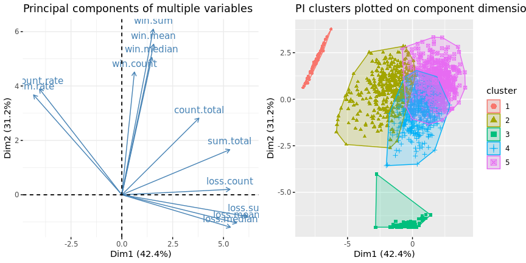

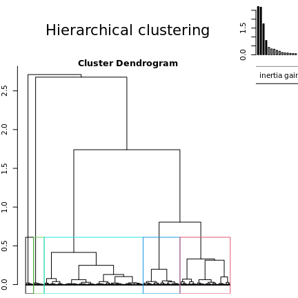

### 7. CLUSTERS DISPLAYED ON SCATTER PLOTS

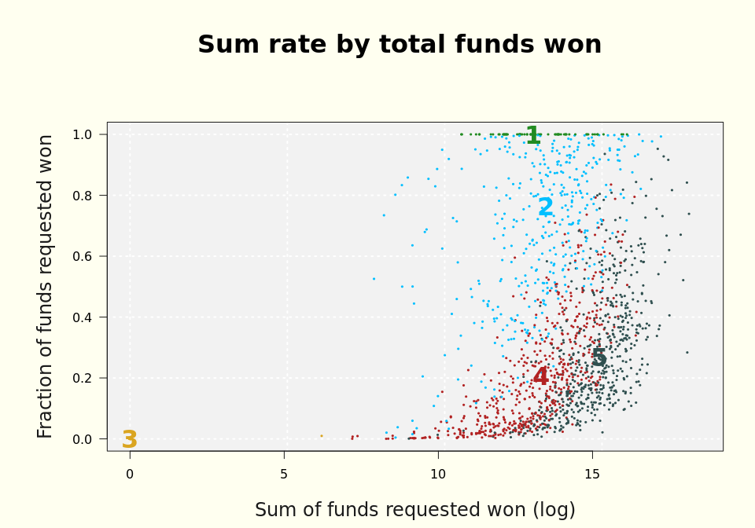

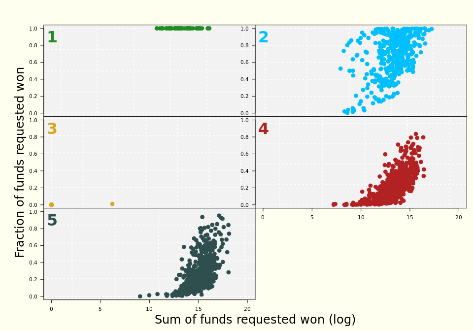

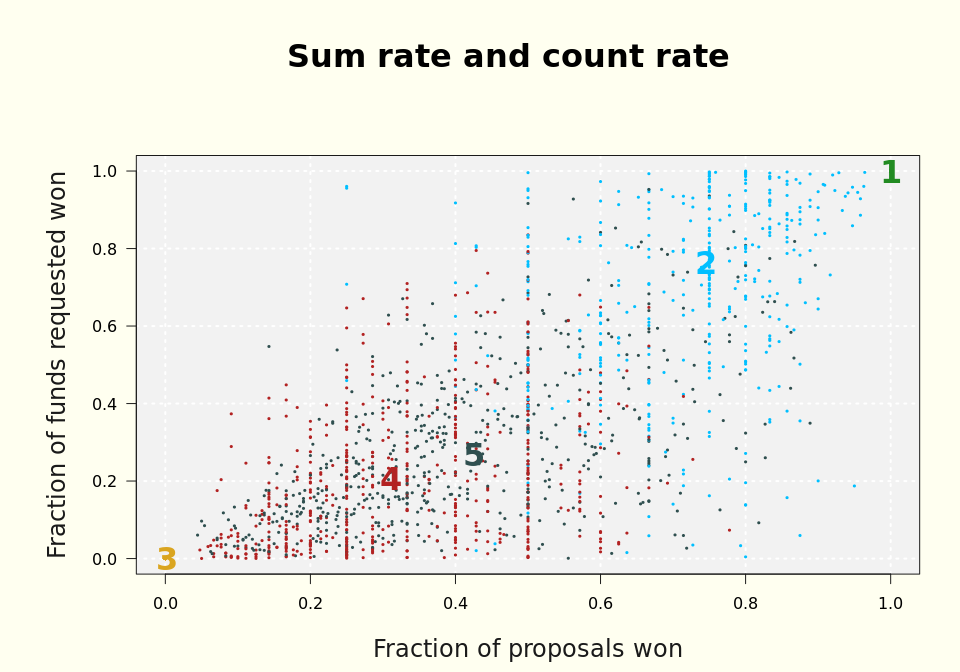

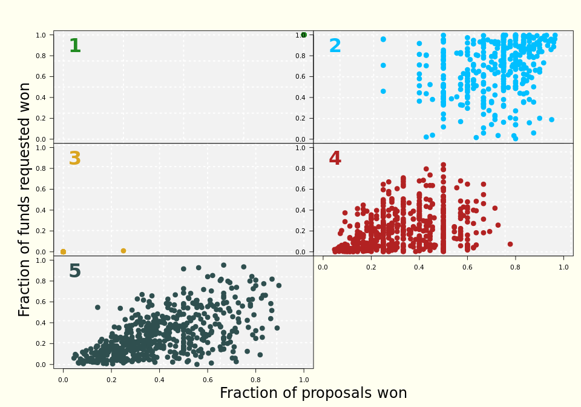

### 8. VARIABLE RELEVANCE PER CLUSTER

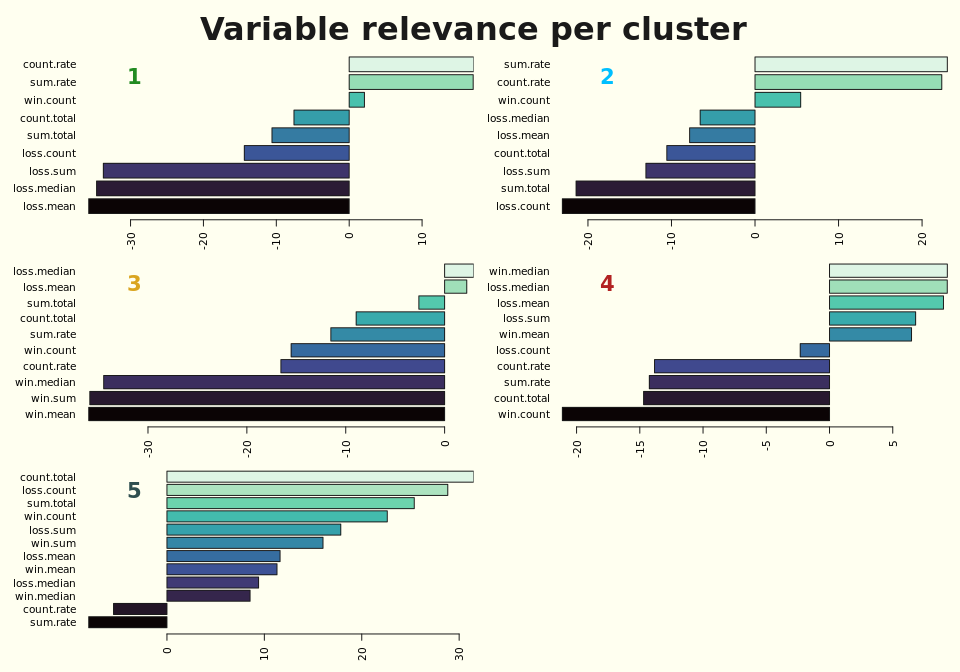

### 9. CLUSTERS OVER TIME

Although this clustering did not include any time variables, the submission patterns by cluster are shown.

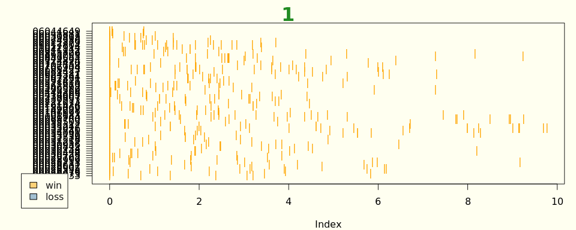

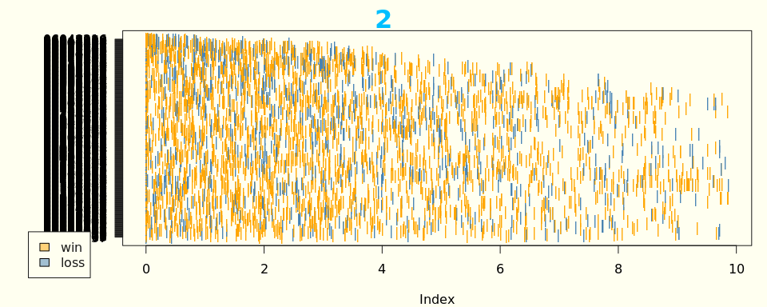

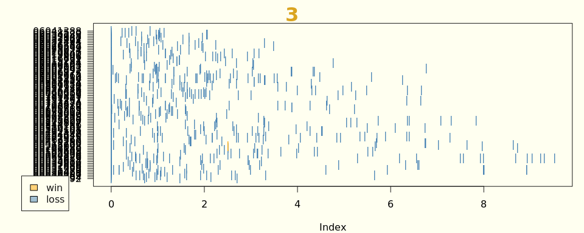

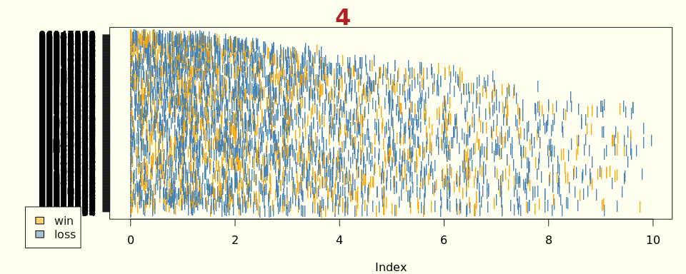

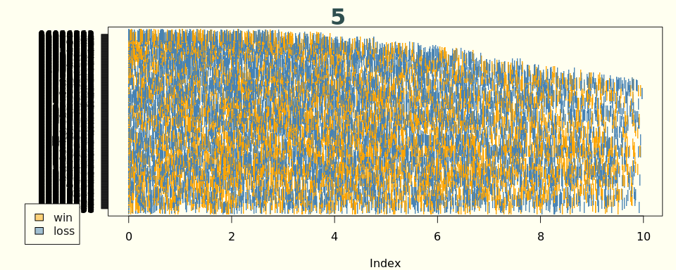

### 10. CLUSTER POPULATIONS BY COLLEGE AND MAJOR INSTITUTIONS

259 (15.5)% PI’s appear in multiple colleges or institutions.

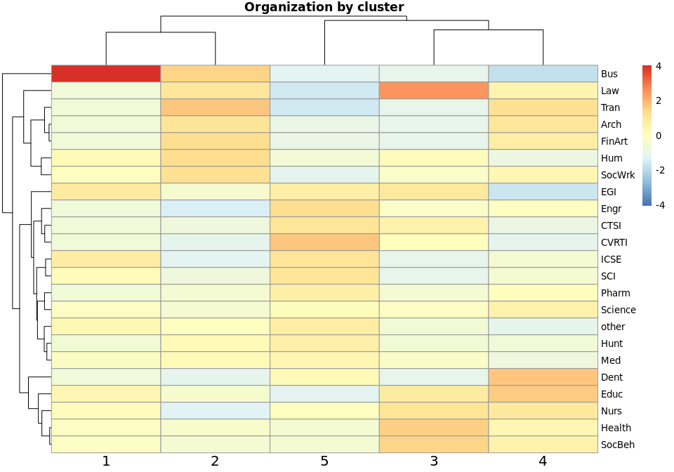

Percent of organization population per cluster

| Org | 1 | 2 | 3 | 4 | 5 |
| --- | --- | --- | --- | --- | --- |
| Arch | 0.0 | 41.2 | 0.0 | 47.1 | 11.8 |
| Bus | 33.3 | 46.7 | 0.0 | 13.3 | 6.7 |
| CTSI | 0.0 | 16.7 | 8.3 | 25.0 | 50.0 |
| CVRTI | 0.0 | 11.1 | 5.6 | 22.2 | 61.1 |
| Dent | 0.0 | 11.1 | 0.0 | 55.6 | 33.3 |
| Educ | 6.9 | 20.7 | 10.3 | 55.2 | 6.9 |
| EGI | 10.5 | 21.1 | 10.5 | 15.8 | 42.1 |
| Engr | 0.4 | 6.8 | 4.3 | 34.9 | 53.6 |
| FinArt | 0.0 | 44.4 | 0.0 | 44.4 | 11.1 |
| Health | 3.6 | 21.4 | 14.3 | 39.3 | 21.4 |
| Hum | 6.2 | 43.8 | 6.2 | 25.0 | 18.8 |
| Hunt | 0.6 | 28.2 | 2.6 | 27.6 | 41.0 |
| ICSE | 10.0 | 10.0 | 0.0 | 30.0 | 50.0 |
| Law | 0.0 | 40.0 | 20.0 | 40.0 | 0.0 |
| Med | 4.0 | 28.1 | 4.4 | 27.2 | 36.4 |
| Nurs | 5.7 | 8.6 | 11.4 | 45.7 | 28.6 |
| other | 6.4 | 25.6 | 2.6 | 21.8 | 43.6 |
| Pharm | 0.0 | 19.4 | 3.2 | 35.5 | 41.9 |
| SCI | 5.4 | 16.2 | 0.0 | 29.7 | 48.6 |
| Science | 3.7 | 19.4 | 4.6 | 41.0 | 31.3 |
| SocBeh | 3.8 | 20.3 | 13.9 | 41.8 | 20.3 |
| SocWrk | 4.3 | 43.5 | 4.3 | 39.1 | 8.7 |
| Tran | 0.0 | 50.0 | 0.0 | 50.0 | 0.0 |

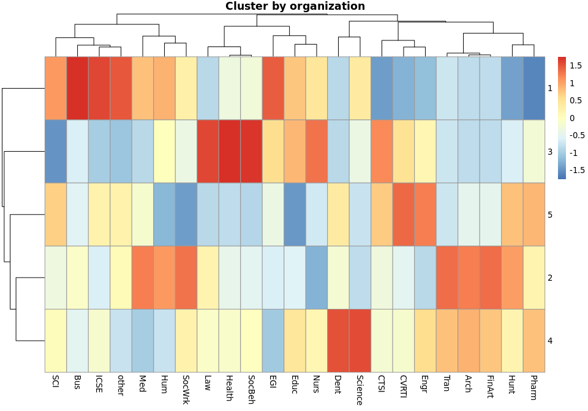

Percent of cluster population per organization

| Org | Arch | Bus | CTSI | CVRTI | Dent | Educ | EGI | Engr | FinArt | Health | Hum | Hunt | ICSE | Law | Med | Nurs | other | Pharm | SCI | Science | SocBeh | SocWrk | Tran |
| --- | --- | --- | --- | --- | --- | --- | --- | --- | --- | --- | --- | --- | --- | --- | --- | --- | --- | --- | --- | --- | --- | --- | --- |
| 1 | 0.0 | 7.5 | 0.0 | 0.0 | 0.0 | 3.0 | 3.0 | 1.5 | 0.0 | 3.0 | 1.5 | 1.5 | 1.5 | 0.0 | 46.3 | 3.0 | 7.5 | 0.0 | 3.0 | 11.9 | 4.5 | 1.5 | 0.0 |
| 2 | 1.6 | 1.6 | 0.9 | 0.4 | 0.2 | 1.3 | 0.9 | 3.6 | 0.9 | 2.7 | 1.6 | 9.9 | 0.2 | 0.4 | 49.1 | 0.7 | 4.5 | 2.7 | 1.3 | 9.4 | 3.6 | 2.2 | 0.2 |
| 3 | 0.0 | 0.0 | 2.1 | 1.0 | 0.0 | 3.1 | 2.1 | 10.4 | 0.0 | 8.3 | 1.0 | 4.2 | 0.0 | 1.0 | 35.4 | 4.2 | 2.1 | 2.1 | 0.0 | 10.4 | 11.5 | 1.0 | 0.0 |
| 4 | 1.3 | 0.3 | 1.0 | 0.7 | 0.8 | 2.6 | 0.5 | 13.4 | 0.7 | 3.6 | 0.7 | 7.0 | 0.5 | 0.3 | 34.5 | 2.6 | 2.8 | 3.6 | 1.8 | 14.5 | 5.4 | 1.5 | 0.2 |
| 5 | 0.3 | 0.1 | 1.7 | 1.6 | 0.4 | 0.3 | 1.1 | 17.8 | 0.1 | 1.7 | 0.4 | 9.0 | 0.7 | 0.0 | 40.1 | 1.4 | 4.8 | 3.7 | 2.5 | 9.6 | 2.3 | 0.3 | 0.0 |